# STAT - In-Class Lab Exercise (Day 2) - Solutions [v1.0 - 080920]

|  | Inclass-Lab (Day 2) |
| --- | --- |

## Table of Content

1. **Parameter Estimation**
2. **Hypothesis Tests with Z Statistic**
3. **Error**

**Import the required libraries**

```python
# import pandas
import pandas as pd

# import 'numpy'
import numpy as np

# import subpackage of matplotlib
import matplotlib.pyplot as plt

# import 'seaborn'
import seaborn as sns

# to suppress warnings
from warnings import filterwarnings
filterwarnings('ignore')

# import statistics to perform statistical computation
import statistics

# import 'stats' package from scipy library
from scipy import stats

# import a library to perform Z-test
from statsmodels.stats import weightstats as stests

# to test the normality
from scipy.stats import shapiro

# import the function to calculate the power of test
from statsmodels.stats import power
```

```python
# set the plot size using 'rcParams'
# once the plot size is set using 'rcParams', it sets the size of all the forthcoming plots in the file
# pass width and height in inches to 'figure.figsize'
plt.rcParams['figure.figsize'] = [15,8]
```

### Let's begin with some hands-on practice exercises

<a id = "est"> </a>

## 1. Parameter Estimation

[figure not shown]

**1. The quality controller at the automobile company needs to know the average length of a steel rod produced in the company. He managed to collect the length (in cm) of 15 rods produced in the last week. Find the point estimate for the average length of the steel rod using sample data.**

Given data:

```
    len_rod (cm) = [25.2, 26.3, 28, 21.9, 23.4, 24, 27.2, 23, 29.2, 28.7, 23.1, 23.5, 26.4, 22.8, 24.7]
```

```python
# given sample data
len_rod = [25.2, 26.3, 28, 21.9, 23.4, 24, 27.2, 23, 29.2, 28.7, 23.1, 23.5, 26.4, 22.8, 24.7]

# the point estimate for the population mean is equal to 'sample mean'
# calculate the sample mean
samp_mean = np.mean(len_rod)

print('The point estimate for the average length of the steel rod is', samp_mean, 'cm')
```

```
The point estimate for the average length of the steel rod is 25.16 cm
```

[output not shown]

Given data:

```
    len_rod (cm) = [25.2, 26.3, 28, 21.9, 23.4, 24, 27.2, 23, 29.2, 28.7, 23.1, 23.5, 26.4, 22.8, 24.7]
```

```python
# given sample data
len_rod = [25.2, 26.3, 28, 21.9, 23.4, 24, 27.2, 23, 29.2, 28.7, 23.1, 23.5, 26.4, 22.8, 24.7]

# the previous question calculates the sample mean as 25.16cm
samp_mean = 25.15

# given population mean
pop_mean = 26

# calculate the sampling error for mean
print("Sampling error for average length of steel rod:", np.abs(samp_mean - pop_mean))
```

```
Sampling error for average length of steel rod: 0.8500000000000014
```

[figure not shown]

**3. The NY university has opened the post of Astrophysics professor. The total number of applications was 36. To check the authenticity of the applicants a sample of 10 applications was collected, out of which 3 applicants were found to be a fraud. Estimate the number of fraud applicants from all the applications.**

```python
# total number of applications
N = 36

# number of applications in a sample
n = 10

# number of fraud applicants in a sample
x = 3

# sample proportion fraud applicants
p_samp = x/n

# estimate the number of fraud applicants
num_fraud = p_samp*N

# round the number to get an integer value
print('The number of fraud applicants:', round(num_fraud))
```

```
The number of fraud applicants: 11
```

[figure not shown]

**4. The production manager at tea emporium wants to estimate the weight of a green tea bag. The previous study shows that the standard deviation of weight is 2.3 g. The manager collects 65 tea bags for the study. How much margin of error the manager should consider to estimate the weight with 99% confidence.**

```python
# sample size
n = 65

# population standard deviaion
std = 2.3

# given alpha
alpha = 0.01

# calculate z_alpha_by_2 with alpha = 0.01
# use 'stats.norm.isf()' to find the Z-value corresponding to the upper tail probability 'q'
# pass the value of 'alpha/2' to the parameter 'q'
# use 'round()' to round-off the value to 4 digits
z_alpha_by_2 = np.abs(round(stats.norm.isf(q = 0.01/2), 4))

# calculate margin of error
error = (z_alpha_by_2*std)/ np.sqrt(n)

print('Margin of error to estimate the weight of green tea bag:', error)
```

```
Margin of error to estimate the weight of green tea bag: 0.7348239395162313
```

[figure not shown]

**5. The bank manager has received several fraud complaints from past a few weeks. The report from accountant states that the standard deviation in frauds is 16. The manager is ready to consider the margin of error as 5. To estimate the average number of frauds with 90% confidence how many transactions should the manager consider?**

```python
# calculate sample size using a given margin of error

# population standard deviation
sigma = 16

# required margin of error
ME = 5

# calculate z-value with alpha = 0.1
# use 'stats.norm.isf()' to find the Z-value corresponding to the upper tail probability 'q'
# pass the value of 'alpha/2' to the parameter 'q'
# use 'round()' to round-off the value to 4 digits
z_alpha_by_2 = np.abs(round(stats.norm.isf(q = 0.1/2), 4))

# calculate sample size (n)
n = ((z_alpha_by_2)**2)*(sigma**2)/(ME**2)

# round-off the value of 'n' to get the integer value
print('Required number of transactions for the fraud detection study:', round(n))
```

```
Required number of transactions for the fraud detection study: 28.0
```

[figure not shown]

**6. A paediatrician wants to check the amount of sugar in the 100g pack of baby food produced by KidsGrow company. The medical journal states that a standard deviation of sugar in 100g pack is 8g. The paediatrician collects 37 packets of baby food and found that the average sugar is 24g. Find the 90% confidence interval for the population mean.**

As the sample size is large (> 30), we use the Z-distribution to calculate the confidence interval.

```python
# number of observations in sample
n = 37

# given sample mean
samp_mean = 24

# given population standard deviation
std_pop = 8

# calculate the 90% confidence interval
# pass the sample mean to the parameter, 'loc'
# pass the scaling factor (std_pop / n^(1/2)) to the parameter, 'scale'
interval = stats.norm.interval(0.90, loc = samp_mean, scale = std_pop / np.sqrt(n))

# print the 90% confidence interval
print('The 90% confidence interval of population mean is:', interval)
```

```
The 90% confidence interval of population mean is: (21.83670183570907, 26.16329816429093)
```

[figure not shown]

**7. The physical trainer at a university wants to estimate the average height of students at the university. The trainer collects the data of 100 students and found that the average height is 168 cm with a standard deviation of 12 cm. Find the 95% confidence interval for the population average height.**

As the sample size is large (> 30), we use the Z-distribution to calculate the confidence interval.

```python
# number of observations in the sample
n = 100

# sample mean
sample_avg = 168

# sample standard deviation
sample_std = 12

# calculate the 95% confidence interval
# pass the sample mean to the parameter, 'loc'
# pass the scaling factor (sample_std / n^(1/2)) to the parameter, 'scale'
# as the population standard deviation is unknown, use the sample standard deviation
interval = stats.norm.interval(0.95, loc = sample_avg, scale = sample_std/np.sqrt(n))

print('95% confidence interval for population average height is', interval)
```

```
95% confidence interval for population average height is (165.64804321855195, 170.35195678144805)
```

[figure not shown]

**8. The health magazine in Los Angeles states that a person should drink 1.8 L water every day. To study this statement, the physician collects the data of 15 people and found that the average water intake for these people is 1.6 L with a standard deviation of 0.5 L. Calculate the 90% confidence interval for the population average water intake.**

As the sample size is small (< 30), we use the t-distribution to calculate the confidence interval.

```python
# number of observations in the sample
n = 15

# given sample mean
sample_avg = 1.6

# given sample standard deviation
sample_std = 0.5

# calculate the 90% confidence interval for the population mean
# pass the 'n-1' degrees of freedom to the parameter, 'df'
# pass the sample mean to the parameter, 'loc'
# pass the scaling factor (sample_std / n^(1/2)) to the parameter, 'scale'
# as the population standard deviation is unknown, use the sample standard deviation
interval = stats.t.interval(0.90, df = n-1, loc = sample_avg, scale = sample_std/np.sqrt(n))

print('90% confidence interval for population mean is', interval)
```

```
90% confidence interval for population mean is (1.3726158392212553, 1.8273841607787449)
```

[figure not shown]

**9. The NY university has opened the post of Astrophysics professor. The total number of applications was 36. To check the authenticity of the applicants a sample of 10 applications was collected, out of which 3 applicants were found to be a fraud. Construct the 95% confidence interval for the population proportion.**

```python
# total number of applications
N = 36

# number of applications in a sample
n = 10

# number of fraud applicants in a sample
x = 3

# sample proportion fraud applicants
p_samp = x/n

# calculate the 95% confidence interval
# pass the sample proportion to the parameter, 'loc'
# pass the scaling factor ((p_samp*(1-p_samp))/n))^0.5) to the parameter, 'scale'
interval = stats.norm.interval(0.95, loc = p_samp, scale = np.sqrt((p_samp*(1-p_samp))/n))

print('95% confidence interval for population proportion is', interval)
```

```
95% confidence interval for population proportion is (0.015974234910674623, 0.5840257650893254)
```

<a id = "eg"> </a>

## 2. Hypothesis Tests with Z Statistic

[figure not shown]

**10. The temperature (in degree Celsius) at Manhattan is recorded for 45 winter days. A student from the Geography department wants to test the claim proposed by the weather department. Check whether the given data satisfies the condition of normality with 99% confidence?**

Use the data given below:

```
temp_winter =  [2.51, 2.6, 1.8, 2.61, 3.9, 1.7, 1.9, 3.1, 1.58, 2.85, 2.9, 1.25, 1.3, 2.4, 3.22, 2.56, 1.32, 1.2, 1.26,
                3.2, 2.7, 3.5, 2.8, 1.5, 3.8, 1.84, 3.31, 1.24, 1.75, 1.41, 1.57, 1.4, 1.49, 2.26, 2.5, 2.52, 3.42, 1.36,
                2.35, 2.47, 2.28, 2.22, 2.66, 3.43, 1.98]
```

The given random sample is the temprature in winter at Manhattan which is continuous in nature. Use the `Shapiro-Wilk test` to check the normality of the data.

```python
# given temprature
temp_winter = [2.51, 2.6, 1.8, 2.61, 3.9, 1.7, 1.9, 3.1, 1.58, 2.85, 2.9, 1.25, 1.3, 2.4, 3.22, 2.56, 1.32, 1.2, 1.26, 3.2,
              2.7, 3.5, 2.8, 1.5, 3.8, 1.84, 3.31, 1.24, 1.75, 1.41, 1.57, 1.4, 1.49, 2.26, 2.5, 2.52, 3.42, 1.36, 2.35,
              2.47, 2.28, 2.22, 2.66, 3.43, 1.98]

# perform Shapiro-Wilk test to test the normality
# shapiro() returns a tuple having the values of test statistics and the corresponding p-value
# pass the sample data to perform the test
stat, p_value = shapiro(temp_winter)

# print the p-value
print('P-Value:', p_value)
```

```
P-Value: 0.03401985391974449
```

From the above result, we can see that the p-value is greater than 0.01, thus we can say that the data is normally distributed.

[output not shown]

Use the data given below:

```
temp_winter =  [2.51, 2.6, 1.8, 2.61, 3.9, 1.7, 1.9, 3.1, 1.58, 2.85, 2.9, 1.25, 1.3, 2.4, 3.22, 2.56, 1.32, 1.2, 1.26,
                3.2, 2.7, 3.5, 2.8, 1.5, 3.8, 1.84, 3.31, 1.24, 1.75, 1.41, 1.57, 1.4, 1.49, 2.26, 2.5, 2.52, 3.42, 1.36,
                2.35, 2.47, 2.28, 2.22, 2.66, 3.43, 1.98]
```

The null and alternative hypothesis is:

H<sub>0</sub>: $\mu \geq 2.8 $  
H<sub>1</sub>: $\mu < 2.8 $

Here ⍺ = 0.01, for a one-tailed test calculate the critical z-value.

```python
# calculate the z-value for 99% of confidence level
# use 'stats.norm.isf()' to find the z-value corresponding to the upper tail probability 'q'
# pass the value of 'alpha' to the parameter 'q', here alpha = 0.01
# use 'round()' to round-off the value to 4 digits
z_val = np.abs(round(stats.norm.isf(q = 0.01), 4))

print('Critical value for one-tailed Z-test:', z_val)
```

```
Critical value for one-tailed Z-test: 2.3263
```

i.e. if z is less than -2.3263 then we reject the null hypothesis.

```python
# given temperature
temp_winter = [2.51, 2.6, 1.8, 2.61, 3.9, 1.7, 1.9, 3.1, 1.58, 2.85, 2.9, 1.25, 1.3, 2.4, 3.22, 2.56, 1.32, 1.2, 1.26, 3.2,
              2.7, 3.5, 2.8, 1.5, 3.8, 1.84, 3.31, 1.24, 1.75, 1.41, 1.57, 1.4, 1.49, 2.26, 2.5, 2.52, 3.42, 1.36, 2.35,
              2.47, 2.28, 2.22, 2.66, 3.43, 1.98]

# 'ztest()' returns the test statistic and corresponding p-value
# pass the sample data to the parameter, 'x1'
# pass the value in null hypothesis to the parameter, 'value'
# pass the one-tailed condition to the parameter, 'alternative'
z_score, pval = stests.ztest(x1 = temp_winter, value = 2.8, alternative = 'smaller')

# print the z-score
print("z_score:", z_score)
```

```
z_score: -4.439552007491998
```

Here the test statistic value is less than -2.3263, thus we reject the null hypothesis and conclude that Manhattan's temperature in winter is less than 2.8 degree celsius.

[figure not shown]

**12. The production manager at the automobile company states that all the steel rods are produced with an average length of 26 cm and a standard deviation of 2.4 cm. The length of 60 rods is collected as a sample and the average length of these rods is found to be 24.8 cm. Test whether the length of the rod is different than 26 cm with a 95% confidence interval.**

The null and alternative hypothesis is:

H<sub>0</sub>: $\mu = 26 $  
H<sub>1</sub>: $\mu ≠ 26 $

```python
# sample size
n = 60

# average length of sample rods
samp_mean = 24.8

# population standard deviaiton
pop_std = 2.4

# calculate the 95% confidence interval for the population mean
# pass the sample mean to the parameter, 'loc'
# pass the scaling factor (pop_std / n^(1/2)) to the parameter, 'scale'
print('95% confidence interval for population mean:', stats.norm.interval(0.95, loc = samp_mean, scale = pop_std / np.sqrt(n)))
```

```
95% confidence interval for population mean: (24.192727370296804, 25.407272629703197)
```

Here the confidence interval do not contain the value in the null hypothesis (i.e. 26), thus we reject the null hypothesis and conclude that the average length of rod is not 26 cm.

[figure not shown]

**13. The production manager at tea emporium claims that the weight of a green tea bag is less than 3.5 g. To test the manager's claim consider a sample of 50 tea bags. The sample average weight is found to be 3.28 g with a standard deviation of 0.6 g. Use the p-value technique to test the claim at a 10% level of significance.**

The null and alternative hypothesis is:

H<sub>0</sub>: $\mu \geq 3.5 $  
H<sub>1</sub>: $\mu < 3.5 $

```python
# define a function to calculate the Z-test statistic
# pass the population mean, sample standard deviation, sample size and sample mean as the function input
def z_test(pop_mean, samp_std, n, samp_mean):

    # calculate the test statistic
    z_score = (samp_mean - pop_mean) / (samp_std / np.sqrt(n))

    # return the z-test value
    return z_score

# given data
n = 50
pop_mean = 3.5
samp_std = 0.6
samp_mean = 3.28

# calculate the test statistic using the function 'z_test'
z_score = z_test(pop_mean, samp_std, n, samp_mean)
print("Z-score:", z_score)
```

```
Z-score: -2.592724864350677
```

```python
# calculate the corresponding p-value for the test statistic
# use 'cdf()' to calculate P(Z <= z_score)
p_value = stats.norm.cdf(z_score)

print('p-value:', p_value)
```

```
p-value: 0.0047609455920493825
```

Here the p-value is less than 0.1, thus we reject the null hypothesis and conclude that the average weight of a green tea bag is less than 3.5 g.

[figure not shown]

**14. The physician at university claims that the average height of male students in the university hostel is more than 175 cm with a standard deviation of 8 cm. To test the claim the physical trainer at a university collects the data of 75 male students in the hostel and calculate the average height of those 75 students as 176.3 cm. Plot the acceptance and rejection region to test the physician's claim at 95% confidence.**

The null and alternative hypothesis is:

H<sub>0</sub>: $\mu \leq 175 $  
H<sub>1</sub>: $\mu > 175 $

Let us plot the acceptance and rejection region for a right-tailed test with 95% confidence.

```python
# define a function to calculate the Z-test statistic
# pass the population mean, population standard deviation, sample size and sample mean as the function input
def z_test(pop_mean, pop_std, n, samp_mean):

    # calculate the test statistic
    z_score = (samp_mean - pop_mean) / (pop_std / np.sqrt(n))

    # return the z-test value
    return z_score

# given data
n = 75
pop_mean = 175
pop_std = 8
samp_mean = 176.3

# calculate the test statistic using the function 'z_test'
z_score = z_test(pop_mean, pop_std, n, samp_mean)
print("Z-score:", z_score)
```

```
Z-score: 1.4072912811497253
```

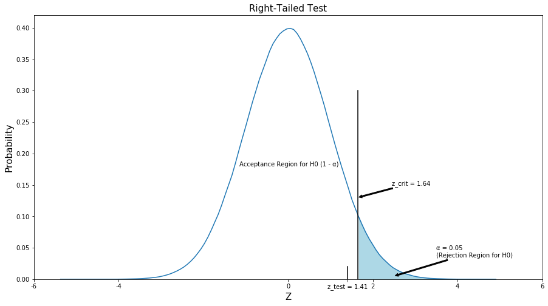

```python
# consider a random variable 'X' that follows a standard normal distribution
# pass the required number of observations to the parameter, 'size'
# set 'random_state' to obtain the same observations every time you run the code
X = stats.norm.rvs(size = 2000000, random_state = 10)

# plot the distribution of X
# pass the data to the parameter, 'a'
# 'hist=False' does not return the histogram
# 'cumulative=False' in 'kde_kws' does not return the cumulative kernel density estimator
ax = sns.distplot(a = X, hist = False, kde_kws = dict(cumulative=False))

# set the limit for y-axis
plt.ylim(0, 0.42)

# use 'stats.norm.isf()' to calculate the critical z-value for alpha = 0.05
# pass the value of 'alpha' to the parameter 'q'
z = stats.norm.isf(q = 0.05)

# plot a vertical line at z-value
x, y = [z, z], [0, 0.3]
plt.plot(x, y, color = 'black')

# plot a vertical line at z-score value
x, y = [z_score, z_score], [0, 0.02]
plt.plot(x, y, color = 'black')

# add the color to the left of the -(z-value)
# get the data for x and y axes for the distribution plot
l1 = ax.lines[0]
x1 = l1.get_xydata()[:,0]
y1 = l1.get_xydata()[:,1]

# fill the color for the region where x-values are greater than z-value
# pass the condition to shade the required region
# pass the required color to the parameter, 'color'
ax.fill_between(x1[x1 >= z], y1[x1 >= z], color = 'lightblue')

# use 'annonate' function to draw an arrow between points xy and xytext
# 's' is a argument to write text
# we can change the facecolor and arrowstyle; this is only for representation purpose
plt.annotate(s = 'α = 0.05\n(Rejection Region for H0)', xy = (2.5, 0.005), xytext = (3.5, 0.035),
             arrowprops = dict(facecolor = 'black', arrowstyle = 'simple'))

plt.annotate(s = 'z_crit = '+ str(round(z,2)), xy = (z, 0.13), xytext = (z+0.8, 0.15),
             arrowprops = dict(facecolor = 'black', arrowstyle = 'simple'))

# use below code to print the values in the graph
# 'x' and 'y' gives position of the text
# 's' is the text
plt.text(x = -1.15, y = 0.18, s = 'Acceptance Region for H0 (1 - α)')

# assign the x-axis labels
# pass the position of labels to the parameter, 'ticks'
# pass the required labels to the parameter, 'labels'
plt.xticks(ticks = [-6, -4, 0, 2, 4, 6, round(z_score,2)],
           labels = [-6, -4, 0, 2, 4, 6, 'z_test = '+str(round(z_score,2))])

# set plot and axes labels
# set text size using 'fontsize'
plt.xlabel('Z', fontsize = 15)
plt.ylabel('Probability', fontsize = 15)
plt.title('Right-Tailed Test', fontsize = 15)

# display the plot
plt.show()
```

The above plot shows that the test statistic value is in the acceptance region, that implies we fail to reject (i.e. accept) $H_{0}$. Thus, there is no enough evidence to conclude that the average height of male students in the university hostel is greater than 175 cm.

[figure not shown]

**15. The quality control department at a soap company states that their herbal soap contains 28 ml of palm oil with a standard deviation of 3.5 ml. A sample of 120 soaps is considered. The average amount of palm oil in the sample is 27.6 ml. Test whether the amount of palm oil is different than 28 ml using the 90% confidence interval.**

The null and alternative hypothesis is:

H<sub>0</sub>: $\mu = 28 $  
H<sub>1</sub>: $\mu \neq 28 $

```python
# sample size
n = 120

# average amount of palm oil in sample soaps
samp_mean = 27.6

# population standard deviaiton
pop_std = 3.5

# calculate the 90% confidence interval for the population mean
# pass the sample mean to the parameter, 'loc'
# pass the scaling factor (pop_std / n^(1/2)) to the parameter, 'scale'
print('90% confidence interval for population mean:', stats.norm.interval(0.90, loc = samp_mean, scale = pop_std / np.sqrt(n)))
```

```
90% confidence interval for population mean: (27.074461329422622, 28.12553867057738)
```

Here the confidence interval contains the value in the null hypothesis (i.e. 28), thus we fail to reject (i.e. accept) the null hypothesis and conclude that the amount of palm oil in the herbal soap is 28 ml.

[figure not shown]

**16. The bank manager claims that the complaints regarding fraud transactions are less than 12 per month with a standard deviation of 3 frauds. To test the claim the sample data for 3 years is collected. The average number of frauds in sample data is 10. Use the critical value method to test the claim with 95% confidence.**

The null and alternative hypothesis is:

H<sub>0</sub>: $\mu \geq 12 $  
H<sub>1</sub>: $\mu < 12 $

Here ⍺ = 0.05, for a one-tailed test calculate the critical z-value.

```python
# calculate the z-value for 95% of confidence level
# use 'stats.norm.isf()' to find the z-value corresponding to the upper tail probability 'q'
# pass the value of 'alpha' to the parameter 'q', here alpha = 0.05
# use 'round()' to round-off the value to 2 digits
z_val = np.abs(round(stats.norm.isf(q = 0.05), 2))

print('Critical value for one-tailed Z-test:', z_val)
```

```
Critical value for one-tailed Z-test: 1.64
```

i.e. if z is less than -1.64 then we reject the null hypothesis.

```python
# define a function to calculate the Z-test statistic
# pass the population mean, population standard deviation, sample size and sample mean as the function input
def z_test(pop_mean, pop_std, n, samp_mean):

    # calculate the test statistic
    z_score = (samp_mean - pop_mean) / (pop_std / np.sqrt(n))

    # return the z-test value
    return z_score

# given data
# sample data for 3 years is considered. i.e. for 36 months
n = 36
pop_mean = 12
pop_std = 3
samp_mean = 10

# calculate the test statistic using the function 'z_test'
z_score = z_test(pop_mean, pop_std, n, samp_mean)
print("Z-score:", z_score)
```

```
Z-score: -4.0
```

Here the z score is less than -1.64. Thus we reject the null hypothesis and conclude that the average frauds per month are less than 12.

[figure not shown]

**17. The internet provider claims that their router gives a speed of 25 Mbps with a standard deviation of 4.8 Mbps. The computer engineer wants to check whether the speed is different than what the provider claims. For this study, the engineer collects the speed of 40 routers and found that the average speed is 23.2 Mbps for those 40 routers. Plot the acceptance and rejection region for a two-sided test to test the claim of engineer with 90% confidence.**

The null and alternative hypothesis is:

H<sub>0</sub>: $\mu = 25 $  
H<sub>1</sub>: $\mu \neq 25 $

Let us plot the acceptance and rejection region for a two-tailed test with 90% confidence.

```python
# define a function to calculate the Z-test statistic
# pass the population mean, population standard deviation, sample size and sample mean as the function input
def z_test(pop_mean, pop_std, n, samp_mean):

    # calculate the test statistic
    z_score = (samp_mean - pop_mean) / (pop_std / np.sqrt(n))

    # return the z-test value
    return z_score

# given data
n = 40
pop_mean = 25
pop_std = 4.8
samp_mean = 23.2

# calculate the test statistic using the function 'z_test'
z_score = z_test(pop_mean, pop_std, n, samp_mean)
print("Z-score:", z_score)
```

```
Z-score: -2.3717082451262854
```

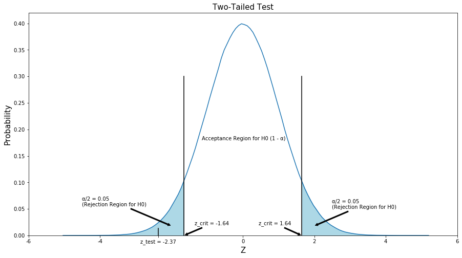

```python
# consider a random variable 'X' that follows a standard normal distribution
# pass the required number of observations to the parameter, 'size'
# set 'random_state' to obtain the same observations every time you run the code
X = stats.norm.rvs(size = 2000000, random_state = 5)

# plot the distribution of X
# pass the data to the parameter, 'a'
# 'hist=False' does not return the histogram
# 'cumulative=False' in 'kde_kws' does not return the cumulative kernel density estimator
ax = sns.distplot(a = X, hist = False, kde_kws = dict(cumulative=False))

# set the limit for y-axis
plt.ylim(0, 0.42)

# use 'stats.norm.isf()' to calculate the critical z-value for alpha = 0.1
# pass the value of 'alpha/2' to the parameter 'q' for a two-tailed test
z = stats.norm.isf(q = 0.1/2)

# plot a vertical line at z-value
x, y = [z, z], [0, 0.3]
plt.plot(x, y, color = 'black')

# plot a vertical line at -(z-value)
x, y = [-z, -z], [0, 0.3]
plt.plot(x, y, color = 'black')

# plot a vertical line at z-score value
x, y = [z_score, z_score], [0, 0.013]
plt.plot(x, y, color = 'black')

# add the color to the right of the z-value and left of -(z-value)
# get the data for x and y axes
l1 = ax.lines[0]
x1 = l1.get_xydata()[:,0]
y1 = l1.get_xydata()[:,1]

# fill the color for the region where x-values are greater than the critical z-value
# pass the condition to shade the required region
# pass the required color to the parameter, 'color'
ax.fill_between(x1[x1 >= z], y1[x1 >= z], color = 'lightblue')

# fill the color for the region where x-values are less than -(z-value)
# pass the condition to shade the required region
# pass the required color to the parameter, 'color'
ax.fill_between(x1[x1 <= -z], y1[x1 <= -z], color = 'lightblue')

# use 'annonate' function to draw an arrow between points xy and xytext
# 's' is a argument to write text
# we can change the facecolor and arrowstyle; this is only for representation purpose
plt.annotate(s = 'α/2 = 0.05\n(Rejection Region for H0)', xy = (2, 0.018), xytext = (2.5, 0.05),
             arrowprops = dict(facecolor = 'black', arrowstyle = 'simple'))

plt.annotate(s = 'α/2 = 0.05\n(Rejection Region for H0)', xy = (-2, 0.018), xytext = (-4.5, 0.055),
             arrowprops = dict(facecolor = 'black', arrowstyle = 'simple'))

plt.annotate(s = 'z_crit = '+ str(round(z,2)), xy = (z, 0), xytext = (z-1.2, 0.02),
             arrowprops = dict(facecolor = 'black', arrowstyle = 'simple'))

plt.annotate(s = 'z_crit = '+ str(round(-z,2)), xy = (-z, 0), xytext = (-z+0.3, 0.02),
             arrowprops = dict(facecolor = 'black', arrowstyle = 'simple'))

# use below code to print the values in the graph
# 'x' and 'y' gives position of the text
# 's' is the text
plt.text(x = -1.15, y = 0.18, s = 'Acceptance Region for H0 (1 - α)')

# assign the x-axis labels
# pass the position of labels to the parameter, 'ticks'
# pass the required labels to the parameter, 'labels'
plt.xticks(ticks = [-6, -4, 0, 2, 4, 6, round(z_score,2)],
           labels = [-6, -4, 0, 2, 4, 6, 'z_test = '+str(round(z_score,2))])

# set plot and axes labels
# set text size using 'fontsize'
plt.xlabel('Z', fontsize = 15)
plt.ylabel('Probability', fontsize = 15)
plt.title('Two-Tailed Test', fontsize = 15)

# display the plot
plt.show()
```

The above plot shows that the test statistic value is in the rejection region, that implies we reject $H_{0}$. Thus it can be concluded that the speed of the router is not 25 Mbps.

[figure not shown]

**18. The health magazine in New York states that every person in NY drinks more than 1.8 L water every day with a standard deviation of 0.5 L. To test this claim the physician collects the data of 45 people and found that the average water intake for these people is 1.93 L. Use the p-value technique to test the claim with 95% confidence.**

The null and alternative hypothesis is:

H<sub>0</sub>: $\mu \leq 1.8 $  
H<sub>1</sub>: $\mu > 1.8 $

```python
# define a function to calculate the Z-test statistic
# pass the population mean, population standard deviation, sample size and sample mean as the function input
def z_test(pop_mean, pop_std, n, samp_mean):

    # calculate the test statistic
    z_score = (samp_mean - pop_mean) / (samp_std / np.sqrt(n))

    # return the z-test value
    return z_score

# given data
n = 45
pop_mean = 1.8
pop_std = 0.5
samp_mean = 1.93

# calculate the test statistic using the function 'z_test'
z_score = z_test(pop_mean, pop_std, n, samp_mean)
print("Z-score:", z_score)
```

```
Z-score: 1.4534441853748623
```

```python
# calculate the corresponding p-value for the test statistic
# use 'sf()' to calculate P(Z > z_score)
p_value = stats.norm.sf(z_score)

print('p-value:', p_value)
```

```
p-value: 0.0730502329817113
```

Here the p-value is greater than 0.05, thus we fail to reject (i.e. accept) the null hypothesis and there is no enough evidence to conclude that the average water intake of an individual is more than 1.8 L.

<a id= "error"></a>

## 3. Error

[figure not shown]

**19. The health magazine in New York states that every person in NY drinks more than 1.8 L water every day with a standard deviation of 0.5 L. To test this claim the physician collects the data of 45 people and found that the average water intake for these people is 1.93 L. Compute the type II error for the test; given that the type I error is 0.05.**

The null and alternative hypothesis is:

H<sub>0</sub>: $\mu \leq 1.8 $  
H<sub>1</sub>: $\mu > 1.8 $

```python
# import the function to calculate the power of test
from statsmodels.stats import power

# number of observationsin sample
num_obs = 45

# given sample mean
samp_mean = 1.93

# null hypothesis value
hypo_mean = 1.8

# population standard deviation
pop_sd = 0.5

# use 'zt_ind_solve_power()' to calculate the power of the z-test
# keep the value of exact one parameter as 'None' to calculate the value of that parameter using remaining values
# calculate the 'effect_size' using the sample_mean, null hypothesis value and population standard deviation
# pass the sample size to the parameter, 'nobs1'
# pass the value of alpha (type I error) to the parameter, 'alpha'
# pass 'None' to the parameter 'power' as we want to calculate its value
# for one sample test, consider the 'ratio' as 0
# pass the alternative for one-tailed test to the parameter, 'alternative'
power = power.zt_ind_solve_power(effect_size = (samp_mean - hypo_mean)/pop_sd,
                         nobs1 = num_obs,
                         alpha = 0.05,
                         power = None,
                         ratio = 0,
                         alternative = 'larger')

# calculate type II error
print('Type II error:', 1 - power)
```

```
Type II error: 0.46045821879740434
```

[figure not shown]

**20. The production manager at the automobile company states that all the steel rods are produced with an average length of 26 cm and a standard deviation of 2.4 cm. The length of 60 rods is collected as a sample and the average length of these rods is found to be 24.8 cm. Calculate the power of the two-sided test with 10% level of significance.**

The null and alternative hypothesis is:

H<sub>0</sub>: $\mu = 26 $  
H<sub>1</sub>: $\mu \neq 26 $

```python
# import the function to calculate the power of test
from statsmodels.stats import power

# number of observations in sample
num_obs = 60

# given sample mean
samp_mean = 24.8

# null hypothesis value
hypo_mean = 26

# population standard deviation
pop_sd = 2.4

# use 'zt_ind_solve_power()' to calculate the power of the z-test
# keep the value of exact one parameter as 'None' to calculate the value of that parameter using remaining values
# calculate the 'effect_size' using the sample_mean, null hypothesis value and population standard deviation
# pass the sample size to the parameter, 'nobs1'
# pass the value of alpha to the parameter, 'alpha'
# pass 'None' to the parameter 'power' as we want to calculate its value
# for one sample test, consider the 'ratio' as 0
# pass the alternative for two-tailed test to the parameter, 'alternative'
power = power.zt_ind_solve_power(effect_size = (samp_mean - hypo_mean)/pop_sd,
                         nobs1 = num_obs,
                         alpha = 0.1,
                         power = None,
                         ratio = 0,
                         alternative = 'two-sided')

print('Power of a two-sided test:', power)
```

```
Power of a two-sided test: 0.9870640841634206
```